# Lab: Data Analysis Workflow Review

Akshay_Gupta_36-600_Lab_14T

This week’s lab is very much do-it-yourself. On `Canvas`, under `Files > DATA`, there is a file called `creditDefault.csv`. Your boss wants to know if any of the variables included in this file, apart from `Default` itself, are important for predicting whether a person will default rather than paying back their credit-card balance.

From the information above, you should construct an appropriate answer. Note that regardless of whether you think a non-ML model is sufficient, you should always check to see if an ML model gives much better predictive results. Also note that your boss is not necessarily looking for plots here…but you’d always want to do *some* EDA, if for no other reason than to ensure you don’t have missing data or outliers!

### Load and Inspect the Data

```r
# Load necessary libraries
suppressPackageStartupMessages(library(tidyverse))
suppressPackageStartupMessages(library(corrplot))

#Load in Data
credit_data <- read.csv("creditDefault.csv")

#Inspect Data
str(credit_data)
```

```
## 'data.frame':    1333 obs. of  4 variables:
##  $ Student: chr  "No" "Yes" "No" "No" ...
##  $ Balance: num  607 528 642 773 1228 ...
##  $ Income : num  44995 17637 30466 34353 37409 ...
##  $ Default: chr  "No" "No" "No" "No" ...
```

```r
summary(credit_data)
```

```
##    Student             Balance         Income        Default
##  Length:1333        Min.   :   0   Min.   : 4985   Length:1333
##  Class :character   1st Qu.: 630   1st Qu.:20781   Class :character
##  Mode  :character   Median :1035   Median :33778   Mode  :character
##                     Mean   :1067   Mean   :33254
##                     3rd Qu.:1497   3rd Qu.:43883
##                     Max.   :2654   Max.   :70701
```

```r
colSums(is.na(credit_data)) # check for 'na' values
```

```
## Student Balance  Income Default
##       0       0       0       0
```

### EDA

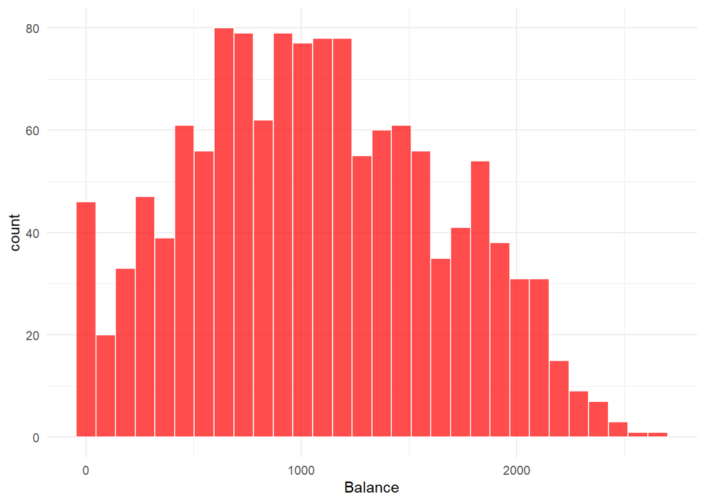

```r
# Encode categorical factors to numeric (0 = No, 1 = Yes)
credit_data$Default <- ifelse(credit_data$Default == "Yes", 1, 0)
credit_data$Student <- ifelse(credit_data$Student == "Yes", 1, 0)

# Visualize continuous variable distributions
ggplot(credit_data, aes(x = Balance)) +
  geom_histogram(bins = 30, fill = "red", color = "white", alpha = 0.7) +
  theme_minimal()
```

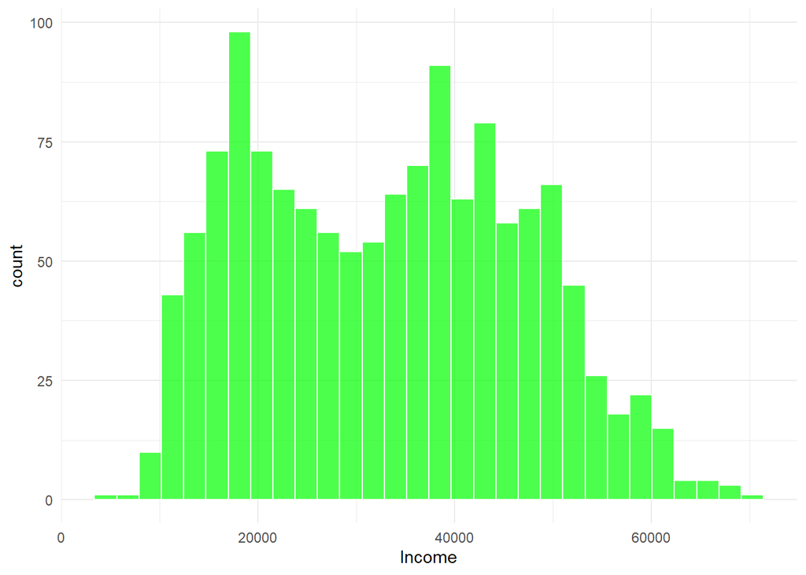

```r
ggplot(credit_data, aes(x = Income)) +
  geom_histogram(bins = 30, fill = "green", color = "white", alpha = 0.7) +
  theme_minimal()
```

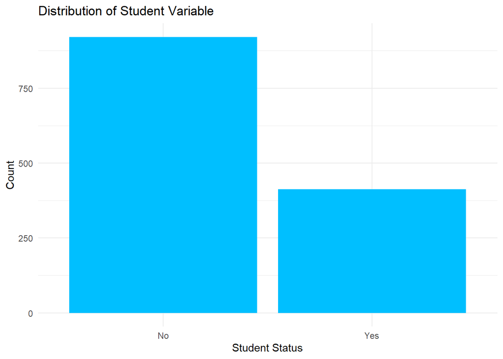

```r
# Distribution of the 'Student' variable
ggplot(credit_data, aes(x = factor(Student, labels = c("No", "Yes")))) +
  geom_bar(fill = "deepskyblue") +
  theme_minimal() +
  labs(title = "Distribution of Student Variable", x = "Student Status", y = "Count")
```

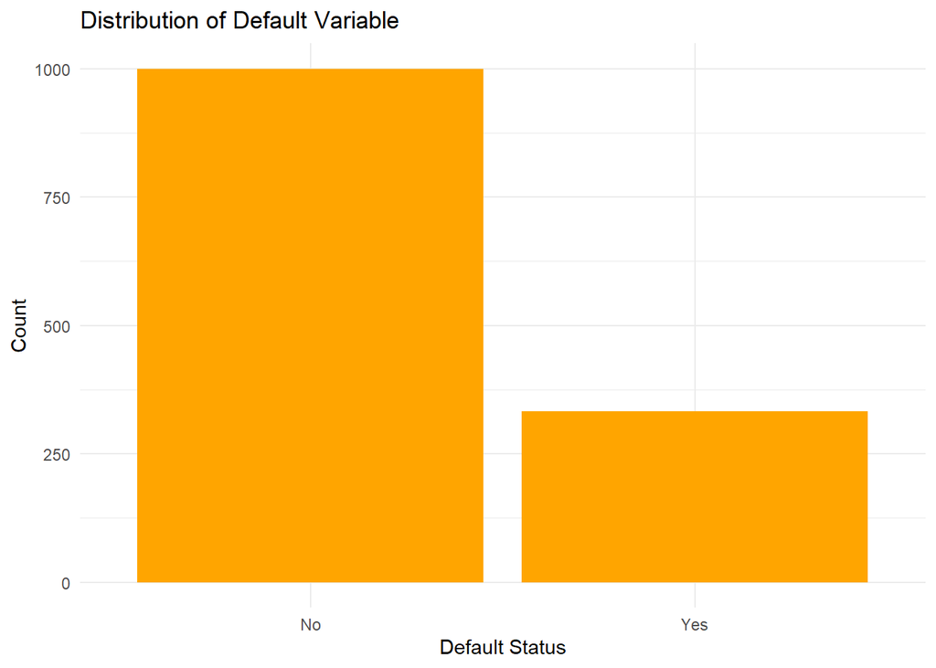

```r
# Distribution of the 'Default' variable
ggplot(credit_data, aes(x = factor(Default, labels = c("No", "Yes")))) +
  geom_bar(fill = "orange") +
  theme_minimal() +
  labs(title = "Distribution of Default Variable", x = "Default Status", y = "Count")
```

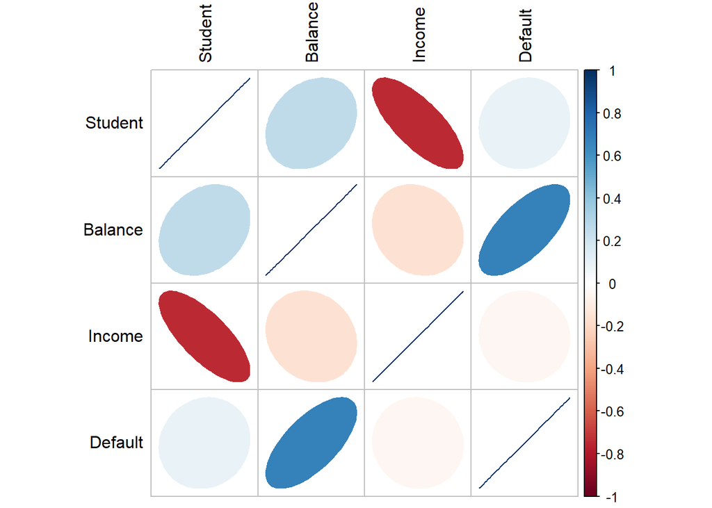

```r
# Correlation matrix (heatmap)
#convert factor data to numeric for corr plot
credit_data$Student <- as.numeric(credit_data$Student)
credit_data$Default <- as.numeric(credit_data$Default)

corr_matrix <- cor(credit_data)
corrplot(corr_matrix, method = "ellipse", tl.col = "black")
```

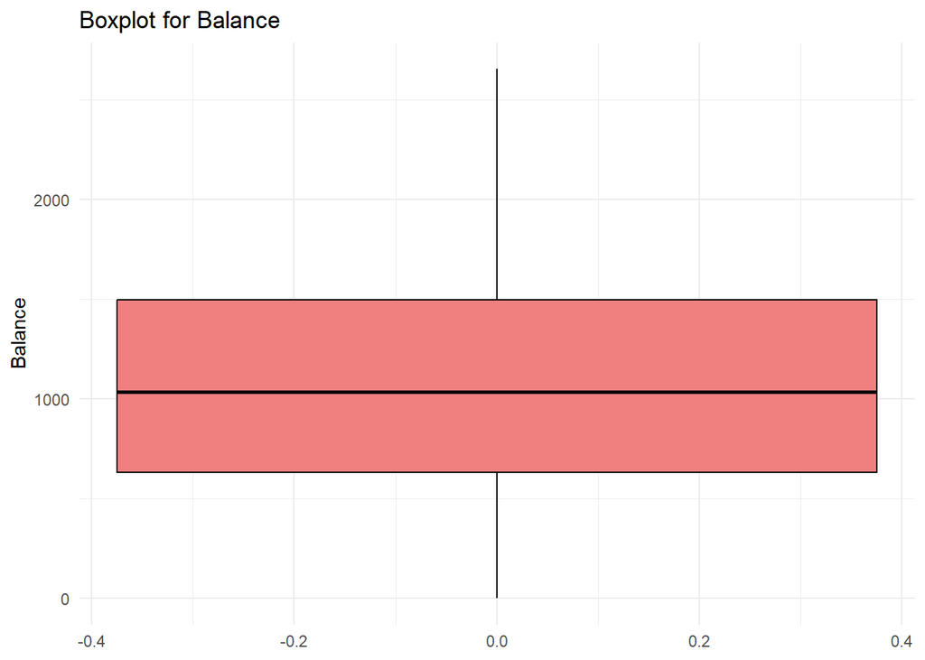

```r
# Convert factor data from numeric back to factor for classification
credit_data$Student <- factor(credit_data$Student, levels = c(0, 1))
credit_data$Default <- factor(credit_data$Default, levels = c(0, 1))


# Outlier Detection with Boxplots

# Boxplot for 'Balance' variable
ggplot(credit_data, aes(y = Balance)) +
  geom_boxplot(fill = "lightcoral", color = "black") +
  theme_minimal() +
  labs(title = "Boxplot for Balance", y = "Balance")
```

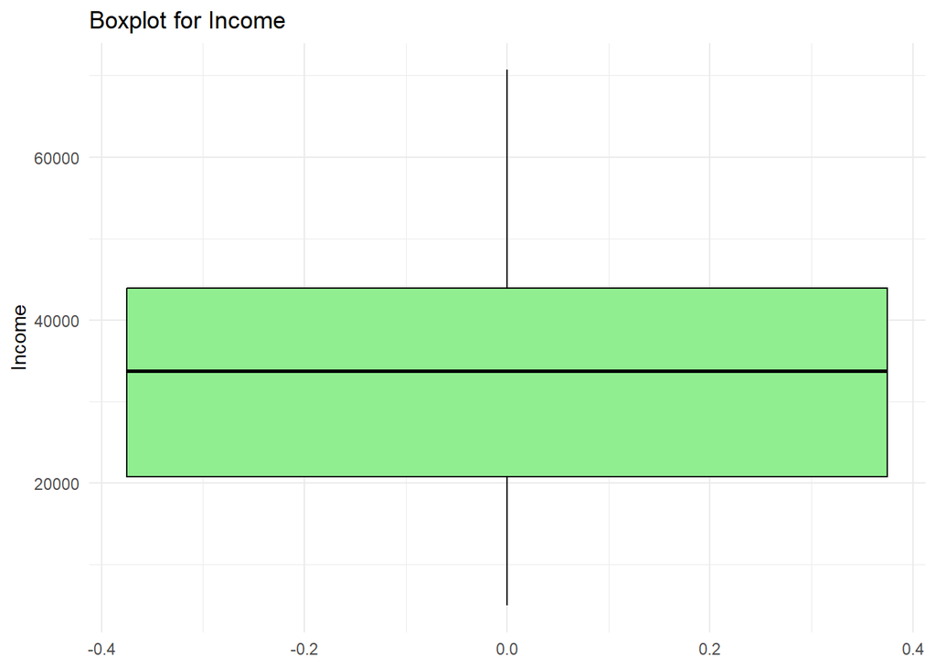

```r
# Boxplot for 'Income' variable
ggplot(credit_data, aes(y = Income)) +
  geom_boxplot(fill = "lightgreen", color = "black") +
  theme_minimal() +
  labs(title = "Boxplot for Income", y = "Income")
```

### Split and Scale Data for Models

```r
# Split Data
set.seed(123) # for reproducibility
train_indices <- sample(1:nrow(credit_data), 0.8 * nrow(credit_data))
train_data <- credit_data[train_indices, ]
test_data <- credit_data[-train_indices, ]

# Min-Max Scaling (using dplyr for convenience)
train_data_scaled <- train_data %>%
  mutate(
    Balance = (Balance - min(Balance)) / (max(Balance) - min(Balance)),
    Income = (Income - min(Income)) / (max(Income) - min(Income))
  )

test_data_scaled <- test_data %>%
  mutate(
    Balance = (Balance - min(train_data$Balance)) / (max(train_data$Balance) - min(train_data$Balance)),
    Income = (Income - min(train_data$Income)) / (max(train_data$Income) - min(train_data$Income))
  )
```

### Linear and ML Models (Logistic and Random Forest)

```r
# Load necessary libraries
suppressPackageStartupMessages(library(randomForest))
suppressPackageStartupMessages(library(caret))
suppressPackageStartupMessages(library(pROC))

# Train the Logistic Regression Model
log_model <- glm(Default ~ Balance + Income + Student, data = train_data_scaled, family = binomial())

# Train the Random Forest Model
rf_model <- randomForest(Default ~ Balance + Income + Student, data = train_data_scaled, importance = TRUE)
```

### Predictions

```r
# Logistic Regression Predictions (probabilities)
log_pred_prob <- predict(log_model, newdata = test_data_scaled, type = "response")

# Logistic Regression Predictions (binary class)
log_pred_class <- ifelse(log_pred_prob > 0.5, 1, 0)

# Random Forest Predictions (binary class)
rf_pred_class <- predict(rf_model, newdata = test_data_scaled)
```

### Performance Metrics and Comparison

```r
# Confusion Matrix for Logistic Regression
log_cm <- confusionMatrix(factor(log_pred_class), factor(test_data_scaled$Default))
print(log_cm$table)  # Print confusion matrix
```

```
##           Reference
## Prediction   0   1
##          0 184  21
##          1  10  52
```

```r
# Extract performance metrics for Logistic Regression
log_accuracy <- log_cm$overall['Accuracy']          # Accuracy
log_precision <- log_cm$byClass['Pos Pred Value']   # Precision
log_recall <- log_cm$byClass['Sensitivity']         # Recall
log_f1 <- log_cm$byClass['F1']                      # F1 Score

cat("Logistic Regression Accuracy: ", log_accuracy, "\n")
```

```
## Logistic Regression Accuracy:  0.8838951
```

```r
cat("Logistic Regression Precision: ", log_precision, "\n")
```

```
## Logistic Regression Precision:  0.897561
```

```r
cat("Logistic Regression Recall: ", log_recall, "\n")
```

```
## Logistic Regression Recall:  0.9484536
```

```r
cat("Logistic Regression F1 Score: ", log_f1, "\n")
```

```
## Logistic Regression F1 Score:  0.9223058
```

```r
# Confusion Matrix for Random Forest
rf_cm <- confusionMatrix(factor(rf_pred_class), factor(test_data_scaled$Default))
print(rf_cm$table)  # Print confusion matrix
```

```
##           Reference
## Prediction   0   1
##          0 188  26
##          1   6  47
```

```r
# Extract performance metrics for Random Forest
rf_accuracy <- rf_cm$overall['Accuracy']          # Accuracy
rf_precision <- rf_cm$byClass['Pos Pred Value']   # Precision
rf_recall <- rf_cm$byClass['Sensitivity']         # Recall
rf_f1 <- rf_cm$byClass['F1']                      # F1 Score

cat("Random Forest Accuracy: ", rf_accuracy, "\n")
```

```
## Random Forest Accuracy:  0.8801498
```

```r
cat("Random Forest Precision: ", rf_precision, "\n")
```

```
## Random Forest Precision:  0.8785047
```

```r
cat("Random Forest Recall: ", rf_recall, "\n")
```

```
## Random Forest Recall:  0.9690722
```

```r
cat("Random Forest F1 Score: ", rf_f1, "\n")
```

```
## Random Forest F1 Score:  0.9215686
```

### Variable Importance Plot for Random Forest

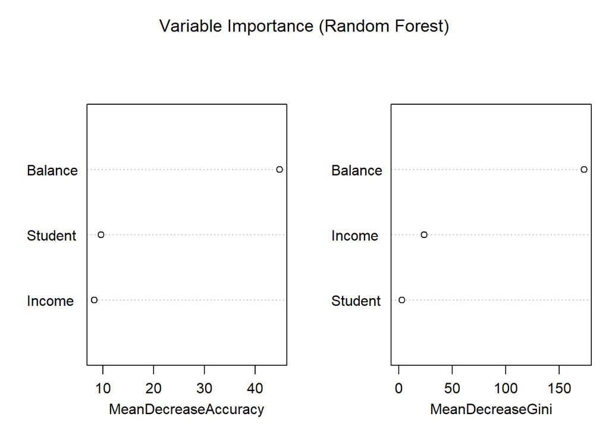

```r
# Plot the variable importance for Random Forest
varImpPlot(rf_model, main = "Variable Importance (Random Forest)")
```

Balance has a strong correlation to Default of about 0.7 as seen in the correlation plot and the variable importance plots for Random Forest. Student and Default do not have a strong correlation. Both Logistic and Random Forest classification models perform similarly well with F1 scores of 0.92.

No missing data, no outliers.